# Health Data Visualization Practice

```r
library(RPostgreSQL)
```

```r
library(ggplot2)
library(tidyverse)
library(ggthemes)
library(ggcorrplot)
library(purrr)

# load the PostgreSQL driver
drv <- dbDriver("PostgreSQL")

# create a connection to the postgres database
# set the search path to the mimiciii schema
con <- dbConnect(drv, dbname = "mimic",
                 host = "localhost", port = 5432,
                 user = "DavidSasson")
dbSendQuery(con, 'set search_path to mimiciii')
```

```
## <PostgreSQLResult>
```

```r
# test connection
# dbExistsTable(con, "patients")

# show a list of tables
dbListTables(con)
```

```
##  [1] "chartevents_1"      "chartevents_2"      "chartevents_3"
##  [4] "chartevents_4"      "chartevents_5"      "chartevents_6"
##  [7] "chartevents_7"      "chartevents_8"      "chartevents_9"
## [10] "chartevents_10"     "chartevents_11"     "chartevents_12"
## [13] "chartevents_13"     "chartevents_14"     "chartevents_15"
## [16] "chartevents"        "admissions"         "callout"
## [19] "caregivers"         "chartevents_16"     "chartevents_17"
## [22] "cptevents"          "datetimeevents"     "diagnoses_icd"
## [25] "drgcodes"           "d_cpt"              "d_icd_diagnoses"
## [28] "d_icd_procedures"   "d_items"            "d_labitems"
## [31] "icustays"           "inputevents_cv"     "inputevents_mv"
## [34] "labevents"          "microbiologyevents" "noteevents"
## [37] "outputevents"       "patients"           "prescriptions"
## [40] "procedureevents_mv" "procedures_icd"     "services"
## [43] "transfers"
```

This snippet makes several assumptions with respect to the way the database is set up.

- `dbname`: It assumes the name of your database is the same as your local username (i.e., the result of `whoami`). If this is not the case, you should pass a different value indicating the name of your database (e.g., `dbname='mimic'`).
- `host`: It assumes the database is hosted locally on your machine (i.e., on `localhost`).
- `port`: It assumes Postgres is listening on the default port, `5432`.
- `user`: It assumes the current user has access to the database.
- `password`: It assumes no password is required for this user, usually because Postgres is using `peer` authentication.

# Data Exploration with ggplot2

```r
admins = dbGetQuery(con, "select * from admissions")

str(admins)
```

```
## 'data.frame':    58976 obs. of  19 variables:
##  $ row_id              : int  21 22 23 24 25 26 27 28 29 30 ...
##  $ subject_id          : int  22 23 23 24 25 26 27 28 30 31 ...
##  $ hadm_id             : int  165315 152223 124321 161859 129635 197661 134931 162569 104557 128652 ...
##  $ admittime           : POSIXct, format: "2196-04-09 12:26:00" "2153-09-03 07:15:00" ...
##  $ dischtime           : POSIXct, format: "2196-04-10 15:54:00" "2153-09-08 19:10:00" ...
##  $ deathtime           : POSIXct, format: NA NA ...
##  $ admission_type      : chr  "EMERGENCY" "ELECTIVE" "EMERGENCY" "EMERGENCY" ...
##  $ admission_location  : chr  "EMERGENCY ROOM ADMIT" "PHYS REFERRAL/NORMAL DELI" "TRANSFER FROM HOSP/EXTRAM" "TRANSFER FROM HOSP/EXTRAM" ...
##  $ discharge_location  : chr  "DISC-TRAN CANCER/CHLDRN H" "HOME HEALTH CARE" "HOME HEALTH CARE" "HOME" ...
##  $ insurance           : chr  "Private" "Medicare" "Medicare" "Private" ...
##  $ language            : chr  NA NA "ENGL" NA ...
##  $ religion            : chr  "UNOBTAINABLE" "CATHOLIC" "CATHOLIC" "PROTESTANT QUAKER" ...
##  $ marital_status      : chr  "MARRIED" "MARRIED" "MARRIED" "SINGLE" ...
##  $ ethnicity           : chr  "WHITE" "WHITE" "WHITE" "WHITE" ...
##  $ edregtime           : POSIXct, format: "2196-04-09 10:06:00" NA ...
##  $ edouttime           : POSIXct, format: "2196-04-09 13:24:00" NA ...
##  $ diagnosis           : chr  "BENZODIAZEPINE OVERDOSE" "CORONARY ARTERY DISEASE\\CORONARY ARTERY BYPASS GRAFT/SDA" "BRAIN MASS" "INTERIOR MYOCARDIAL INFARCTION" ...
##  $ hospital_expire_flag: int  0 0 0 0 0 0 0 0 0 1 ...
##  $ has_chartevents_data: int  1 1 1 1 1 1 1 1 1 1 ...
```

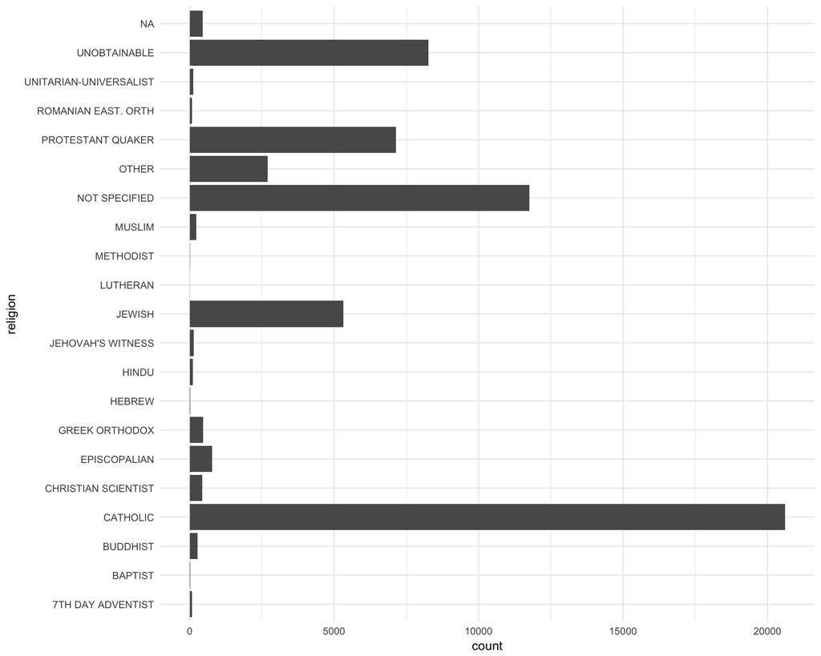

```r
x <- ggplot(admins)

x + geom_bar(aes(religion)) + coord_flip() + theme_minimal()
```

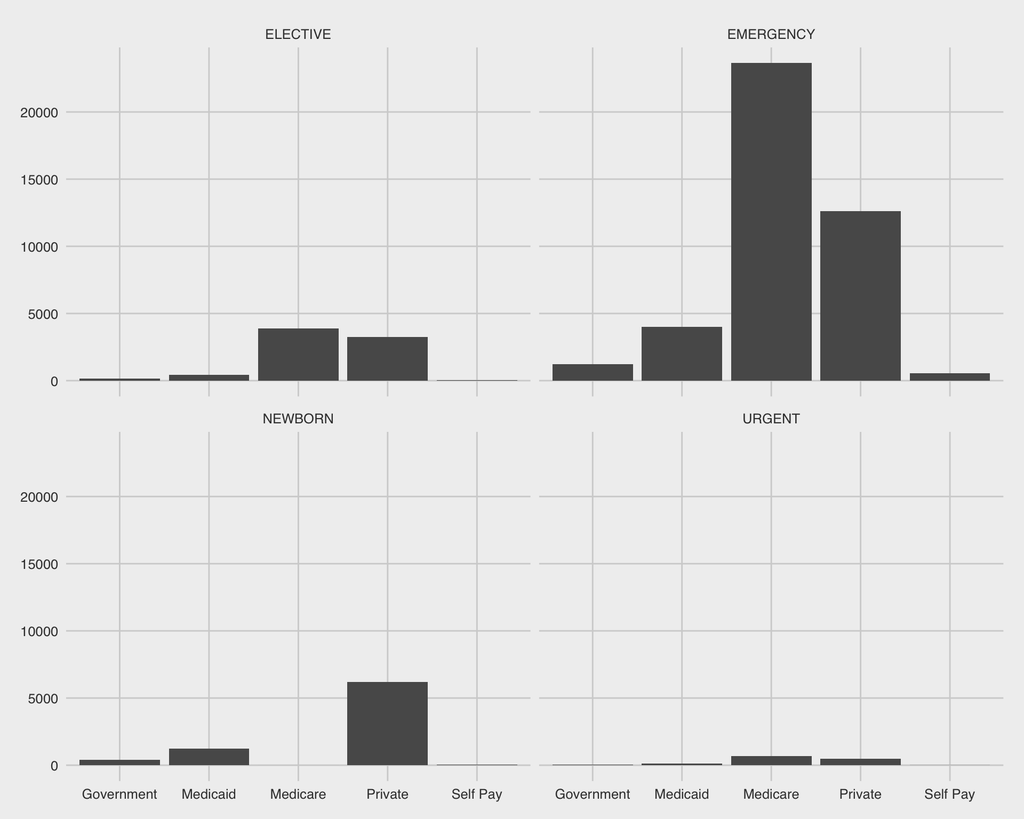

```r
x + geom_bar(aes(insurance)) + facet_wrap(~ admission_type) + theme_fivethirtyeight()
```

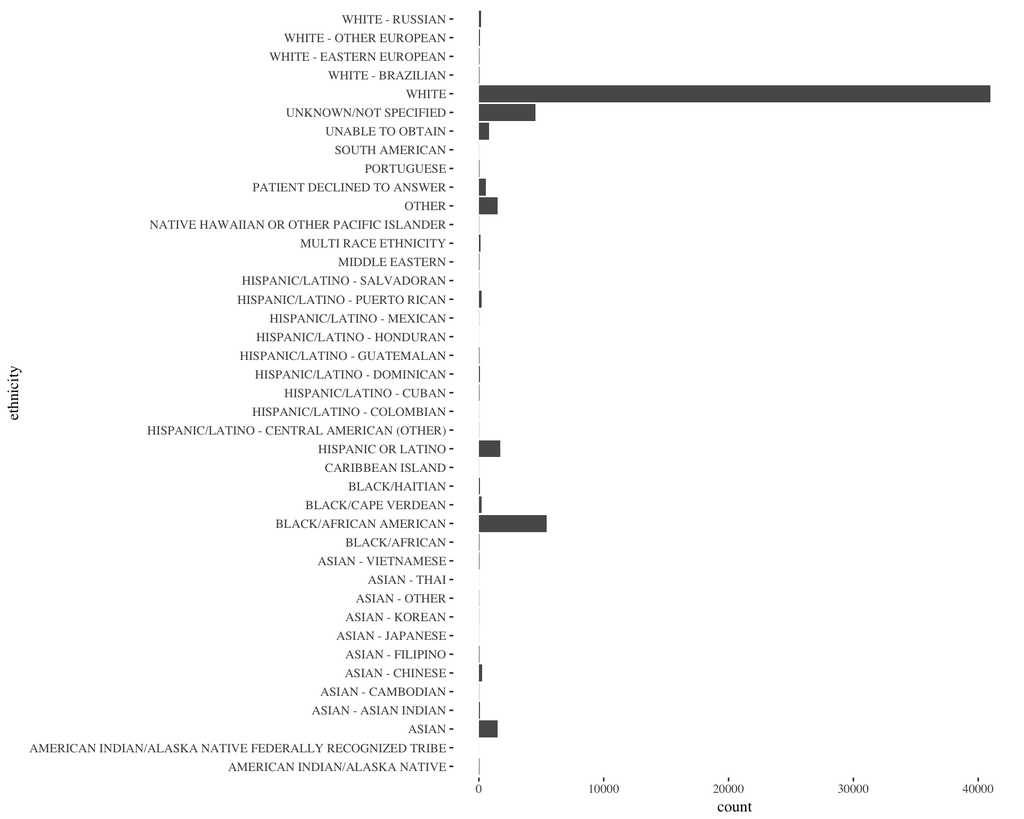

```r
x + geom_bar(aes(ethnicity)) + coord_flip() + theme_tufte()
```

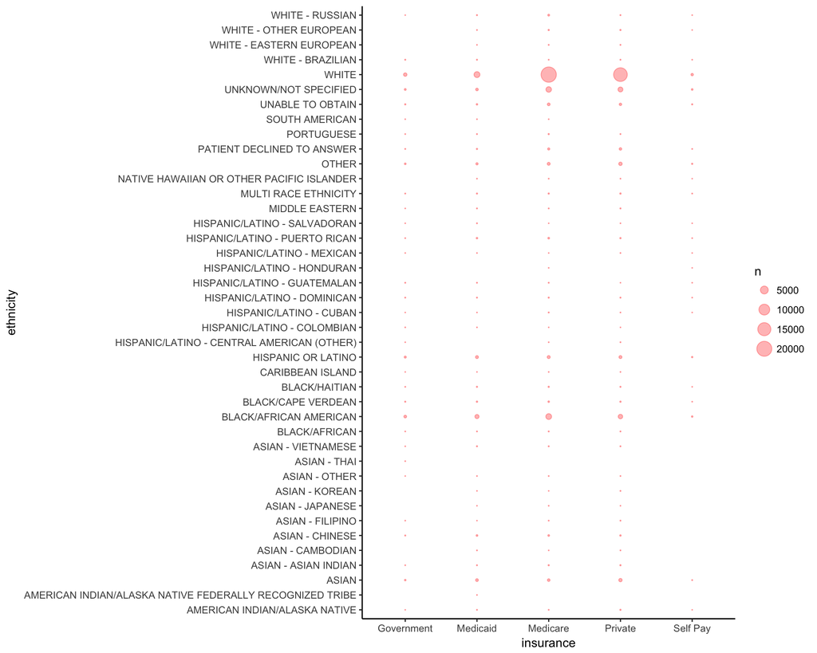

```r
x + geom_count(aes(x = insurance, y = ethnicity), alpha=0.3, col="red") +
  scale_size_area() +
  theme_classic()
```

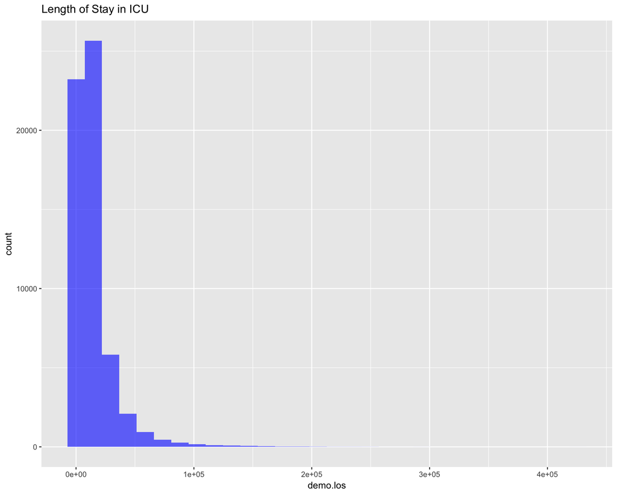

```r
demo.los <- as.numeric(admins$dischtime - admins$admittime)

ggplot() +
  geom_histogram(aes(demo.los), alpha=0.6, fill=4, bins = 30) +
  ggtitle("Length of Stay in ICU")
```

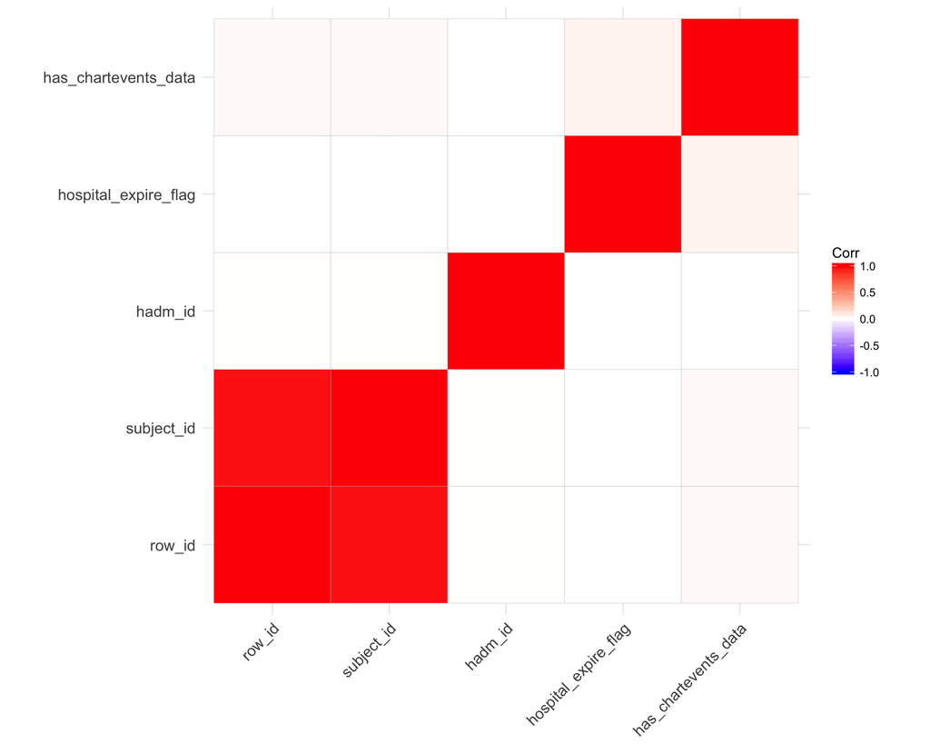

```r
# keep only numeric columns
nums <- admins %>% keep(is.numeric)

ggcorrplot(cor(nums))
```

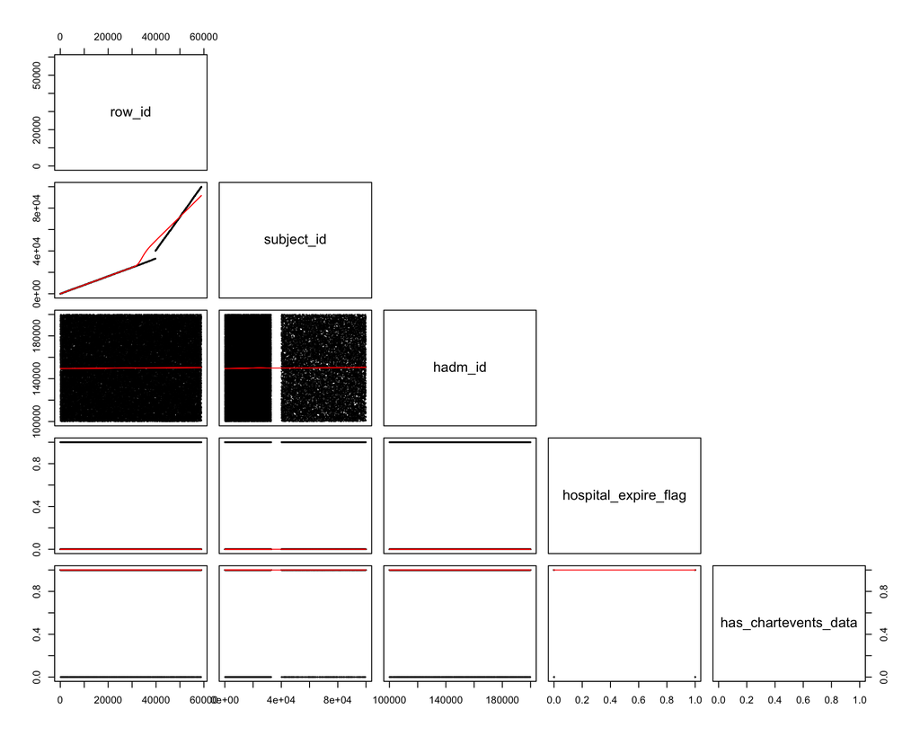

```r
pairs(nums, pch =19, lower.panel=panel.smooth, cex = 0.1, upper.panel = NULL)
```

Full disclosure–I put together this presentaion on my flight over here yesterday :) below is some scratch that didn’t make it into the pretty graphs above. I’m including it to show you what my thought process is and what real data exploration looks like. It sure as hell ain’t coherent, but you’ll always end up with an interesting answer if you keep digging through the data. *Bonus points* to whoever makes cool vizzes with these *Bonus points mean nothing, but I will really like you as a person*

```r
# look at time difference. why is this straight line? Maybe look at boxplot of diffs for each subject
# x + geom_point(aes(admittime, deathtime), alpha=0.3)

# This takes too long but should be investigated. ~ 15,000 diagnosis codes?
# need to find which 15 are most common and shop
# x + geom_bar(aes(diagnosis)) + coord_flip()
#
# unique(admins$diagnosis)
# [1000] "CORONARY ARTERY DISEASE\\CORONARY ARTERY BYPASS GRAFT; ? OFF PUMP/SDA"
# [ reached getOption("max.print") -- omitted 14692 entries ]
```

```r
dbListTables(con)
```

```
##  [1] "chartevents_1"      "chartevents_2"      "chartevents_3"
##  [4] "chartevents_4"      "chartevents_5"      "chartevents_6"
##  [7] "chartevents_7"      "chartevents_8"      "chartevents_9"
## [10] "chartevents_10"     "chartevents_11"     "chartevents_12"
## [13] "chartevents_13"     "chartevents_14"     "chartevents_15"
## [16] "chartevents"        "admissions"         "callout"
## [19] "caregivers"         "chartevents_16"     "chartevents_17"
## [22] "cptevents"          "datetimeevents"     "diagnoses_icd"
## [25] "drgcodes"           "d_cpt"              "d_icd_diagnoses"
## [28] "d_icd_procedures"   "d_items"            "d_labitems"
## [31] "icustays"           "inputevents_cv"     "inputevents_mv"
## [34] "labevents"          "microbiologyevents" "noteevents"
## [37] "outputevents"       "patients"           "prescriptions"
## [40] "procedureevents_mv" "procedures_icd"     "services"
## [43] "transfers"
```

```r
stays = dbGetQuery(con, "select * from icustays")

str(stays)
```

```
## 'data.frame':    61532 obs. of  12 variables:
##  $ row_id        : int  365 366 367 368 369 370 371 372 373 374 ...
##  $ subject_id    : int  268 269 270 271 272 273 274 275 276 277 ...
##  $ hadm_id       : int  110404 106296 188028 173727 164716 158689 130546 129886 135156 171601 ...
##  $ icustay_id    : int  280836 206613 220345 249196 210407 241507 254851 219649 206327 272866 ...
##  $ dbsource      : chr  "carevue" "carevue" "carevue" "carevue" ...
##  $ first_careunit: chr  "MICU" "MICU" "CCU" "MICU" ...
##  $ last_careunit : chr  "MICU" "MICU" "CCU" "SICU" ...
##  $ first_wardid  : int  52 52 57 52 57 52 12 7 57 56 ...
##  $ last_wardid   : int  52 52 57 23 57 52 12 7 57 56 ...
##  $ intime        : POSIXct, format: "2198-02-14 23:27:38" "2170-11-05 11:05:29" ...
##  $ outtime       : POSIXct, format: "2198-02-18 05:26:11" "2170-11-08 17:46:57" ...
##  $ los           : num  3.25 3.28 2.89 2.06 1.62 ...
```

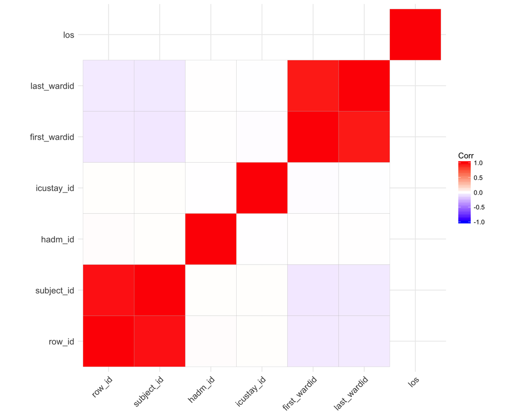

```r
t <- ggplot(stays)

# keep only numeric columns
nums <- stays %>% keep(is.numeric)

ggcorrplot(cor(nums))
```

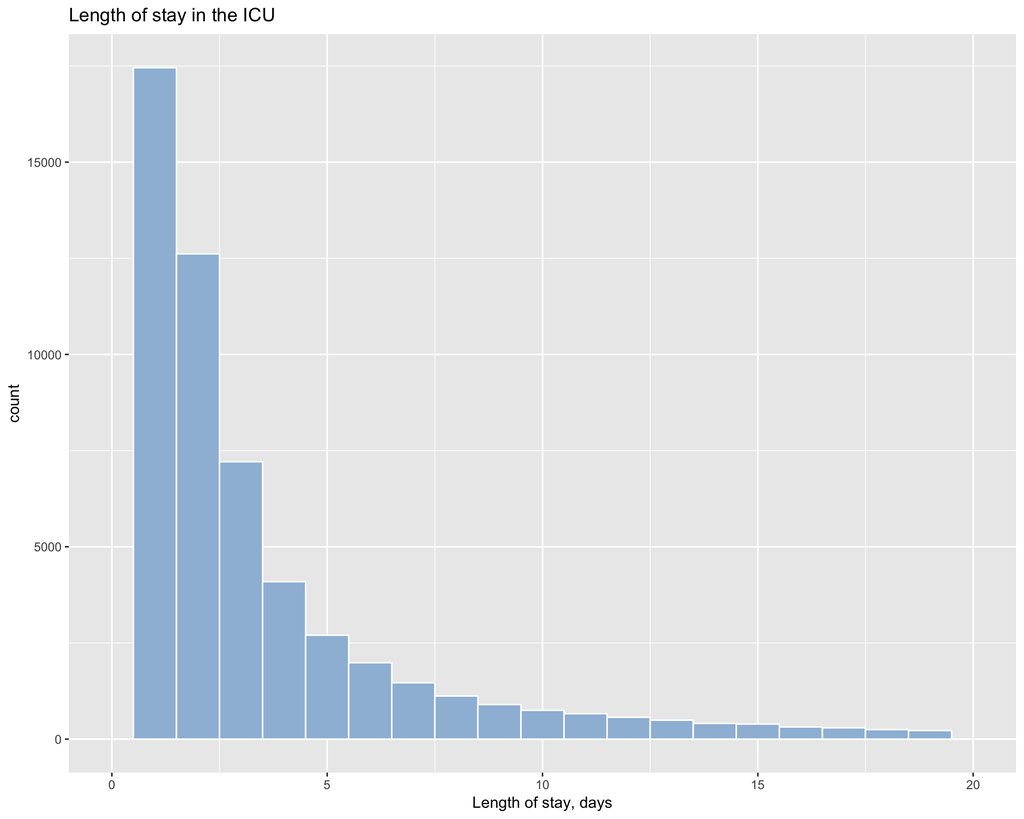

```r
# plot histogram of length of stay in the ICU
t + geom_histogram(aes(los), binwidth = 1, fill=I("#9ebcda"), col=I("#FFFFFF")) +
  xlim(c(0,20)) +
  ggtitle("Length of stay in the ICU") +
  xlab("Length of stay, days")
```

##### Optional Break

Anything you guys are intersted in exploring in MIMIC? If so, let’s do it together! I promise you’ll see me make mistakes every step of the way, but I think we have enough brainpower in this room to find something cool.

```r
dbListTables(con)
```

```
##  [1] "chartevents_1"      "chartevents_2"      "chartevents_3"
##  [4] "chartevents_4"      "chartevents_5"      "chartevents_6"
##  [7] "chartevents_7"      "chartevents_8"      "chartevents_9"
## [10] "chartevents_10"     "chartevents_11"     "chartevents_12"
## [13] "chartevents_13"     "chartevents_14"     "chartevents_15"
## [16] "chartevents"        "admissions"         "callout"
## [19] "caregivers"         "chartevents_16"     "chartevents_17"
## [22] "cptevents"          "datetimeevents"     "diagnoses_icd"
## [25] "drgcodes"           "d_cpt"              "d_icd_diagnoses"
## [28] "d_icd_procedures"   "d_items"            "d_labitems"
## [31] "icustays"           "inputevents_cv"     "inputevents_mv"
## [34] "labevents"          "microbiologyevents" "noteevents"
## [37] "outputevents"       "patients"           "prescriptions"
## [40] "procedureevents_mv" "procedures_icd"     "services"
## [43] "transfers"
```